# Covariates, PAPs, Ethical Design

### Recap of the class so far:

- Random assignment allows us to make causal inferences about the effects of treatment on outcomes
  - Random assignment essentially samples of all potential control and potential treatment outcomes. Taking the difference yields and unbiased estimate of the ATE
  - Thought of another way: random assignment ensures that, on average, treatments are uncorrelated with (observed and unobserved) confounders
  - Random assignment also underlies the logic of statistical hypothesis testing using randomization inference
- Blocking and pre-post designs can increase the precision of our estimates of the ATE
  - These techniques can be used to increase the statistical power of our experiment (that is, the likelihood of detecting a statistically significant treatment effect one a “true” difference in fact exists)

Today, we will extend these ideas by discussing how to (responsibly) incorporate covariates within a regression framework.

We will talk about how covariates can also be used to check the success of our randomization procedures.

### Covariates and Regression

Blocking and pre-tests are extremely helpful in small experiments.

But in sufficiently large samples, regression will give you basically the same result.

- You should aim to have at least 20 more observations than covariates in your model.

Regression has the added advantage that you can control for several covariates simultaneously.

Note that, unlike treatment effects, covariates have no causal interpretation. In other words, covariates predict outcomes. They do not affect outcomes.

### Covariate balance

When using covariates, we want to make sure that they are collected **prior** to treatment. Any covariates which are measured after treatment could be themselves by the treatment.

Since covariates are measured before treatment, they should not be systematically related to treatment assignment. In fact, we can test whether covariates are balanced between treatment and control groups.

**Class exercise**

Download the [40 schools data](https://nanzhangresearch.github.io/40schools.csv) again from last week. Use randomization inference to test the sharp null hypothesis that treatment assignment Z has no effect on pre-treatment scores X for any school.

With multiple covariates, you could do this exercise for each single covariate.

Or you could just regress the treatment on all of the covariates and calculate the F-statistic (testing the null hypothesis that the covariates predict the treatment assignments no better than would be expected by chance.)

### What if the balance test “fails”?

The random assignment of any finite number of observations inevitably produces some degree of imbalance, or correlation between the assigned treatment and one or more covariates.

After all, a p-value of 0.05 implies that you will obtain a statistically significant difference purely by chance 1 out of 20 times.

If imbalance arises, you should double check that your randomization procedures were correctly implemented. Potential deviations from your randomization procedure will depend on the exact details of your experiment…

Assuming your randomization procedure is sound, just control for the covariate to re-establish balance between treatment and control groups. In your paper, you should report estimates with and without covariates.

Of course, if you had information on covariates before **treatment assignment**, you could “throw away” randomizations that produce imbalance on covariates (or just block). But just make sure that you don’t include these “throw aways” in your list of potential randomizations when conducting RI.

### Don’t Phish

Do NOT look at outcomes when deciding which covariates to include in your regression models.

We all have had the experience of “exploring” a variety of regression models that use different combinations of covariates to see how our results change.

This type of analysis introduces an element of discretion in terms of what results are reported. Perhaps unconsciously, you may be drawn to a regression model that makes the estimated ATE look impressive or interesting. But this practice jeopardizes the unbiasedness of the estimator.

Consider this example:

| Study | No Covariates | With Covariates |
| --- | --- | --- |
| 1 | 5 | 4 |
| 2 | 3 | 3 |
| 3 | 2 | 3 |
| 4 | 6 | 5 |
| 5 | 1 | 1 |
| 6 | 0 | -1 |
| 7 | -3 | -1 |
| 8 | -5 | -3 |
| 9 | 0 | -2 |
| Average | 1.00 | 1.00 |
| SD | 3.54 | 2.87 |

Suppose the true ATE is 1.0.

The table reports the estimated ATE from nine experiments.

Each study produces two estimates, one based on a simple difference-in-means and another using regression to control for covariates.

Notice that both estimators generate unbiased estimates, but covariate adjustment has a slight edge in terms of precision.

Suppose the researchers conducting each study use the following decision rule: “Estimate the ATE using both estimators and report whichever estimate is larger (in absolute value)”

Under this reporting policy, what would be the (meta-analytic) ``average effect” in the literature?

### Pre-Analysis Plans

To resist the temptation to phish (or defend against the appearance of phishing), you should plan your covariate adjustment procedures in advance using a pre-analysis plan.

In this way, you “tie your own hands” with respect to modelling choices. You cannot cannot pick and choose results depending on whether they “look good” or generate statistically significant estimates. Commitment to a plan therefore helps make results more credible.

You can use PAP templates available from [OSF](https://help.osf.io/article/158-create-a-preregistration).

Just write out the models you will be estimating (in Greek), or even put in the STATA / R code that you will use to analyse the data and make your tables and graphics.

**Importantly**, having a PAP does not mean that you can no longer explore your data. You just should clearly flag in your paper which sets of analyses were pre-registered, and which ones are “exploratory” or *post hoc*.

### Ethical Design

So far, we have talked about experimental design in terms of their statistical properties.

But experiments also implicate ethical concerns.

We also need to build ethical thinking into the design of our experiments.

Of course, the University of Mannheim has an [ethics commission](https://www.uni-mannheim.de/universitaet/organisation/organe-und-gremien/kommissionen-und-ausschuesse/ethikkommission/), with a form to fill out to obtain ethics approval.

Obtaining ethics approval is important, not only as a “gateway” to publication, but also because the IRB should stand behind you should something go wrong with your research.

However, the IRB is a floor, and not a ceiling. Ultimately, you are the researcher, and the ethical responsibility lies with you; it is your name on the paper.

So you should be able to move beyond an IRB checklist and develop some principles for thinking through ethical trade-offs involved in your own research.

You should also be able to communicate your reasoning with other researchers and the public.

### Principle 1: Respect for Persons

This principle means researchers should not do things to people without their consent. Even if a treatment is harmless or beneficial, participants —- not researchers – should get to decide.

In practice, researchers should, if possible, receive informed consent from participants.

Informed consent means that participants should be presented with relevant information in a comprehensible format and then should voluntarily agree to participate.

However, informed consent may not always be possible, and IRB may waive this requirement for experiments that expose subjects to “minimal risks”.

For instance:

- Sometimes having fully informed consent before the study begins could compromise the scientific value of the study. Think about studies measuring racial discrimination. But couldn’t researchers debrief “participants” after the study is over and obtain consent “after the fact”?
- Sometimes it is logistically impractical to obtain informed consent from everyone impacted by your study. Here, think about a typical “lost letter” experiment.

**Class Exercise**

Take a moment to read the following short [study](https://nanzhangresearch.github.io/emotional_contagion.pdf).

Note that:

1. participants did not provide any consent beyond the standard Facebook terms of service,
2. the study had not undergone meaningful third-party ethical review

What do you think about the ethics of these choices?

### Principle 2: Beneficence

Beneficence is about understanding and improving the risk/benefit profile of your study, and then deciding if it strikes the right balance.

Or, to put it more simply, researchers should attempt to maximize benefits while minimizing harms.

Often, you will be asked about the risks and benefits of your study. Analysis of risk should include two elements: the probability of adverse events and the severity of those events.

As the result of a risk/benefit analysis, a researcher could adjust the study design to reduce the probability of an adverse event (e.g., screen out participants who are vulnerable) or reduce the severity of an adverse event if it occurs (e.g., make counseling available to participants who request it).

Of course, here you are making decisions under uncertainty. It’s often hard to know the exact value of a risk. That’s why researchers have developed a **minimal risk standard** to benchmark the risk of a particular study against the risks that participants undertake in their daily lives, such as playing sports and driving cars.

**Class Exercise**

Think again about the Emotional Contagion study:

1. What risks might have been triggered?
2. What benefits could have arisen from this study?
3. How well do you think the risks and benefits are balanced?

To help you weigh the risks and benefits, you might also want to conduct a short **ethical-response survey** amongst both colleagues and non-scientists:

1. “If someone you cared about were a candidate participant for this experiment, would you want that person to be included as a participant?”
2. Do you believe that the researchers should be allowed to proceed with this experiment?”

By conducting a survey before the experiment, you can prevent problems before the research starts. Second, non-scientists can help you see your study from the perspective of the public.

You can also think about posing multiple versions of the experiment (treat your survey like a survey experiment) to assess the perceived ethical balance of different versions of the same project.

Here are some more general ideas that you might find useful:

- Whenever possible, induce what you believe to be helpful treatments. In Emotional Contagion, the researchers could have *censored* negative words, while *adding* positive words.
- Conduct a power analysis, and then implement the *smallest possible experiment* that you can get away with.

### Principle 3: Justice

Justice is about ensuring that the risks and benefits of research are distributed fairly.

In the past, this was largely about protecting vulnerable people from researchers.

More and more though, it’s now about making sure that vulnerable populations have access to the benefits of research.

In Emotional Contagion, the participants who bore the burden of the research were a random sample from the population most likely to benefit from the results (namely, Facebook users).

### Some common sense:

Often researchers are so focused on the scientific aims of their work that they see the world only through that lens. This myopia can lead to bad ethical judgment.

When you are thinking about your study, try to imagine how your participants, other relevant stakeholders, and even a journalist might react to your study.

Ask yourself: would I be comfortable if my research procedures were written about on the front page of my home town newspaper?

Consider the following experiment:

In November 2007, Researcher X sent letters about an upcoming election to everyone in three towns in the US. In two towns — Monticello, Iowa and Holland, Michigan — X promised to publish a list of people who had voted in the newspaper. In the third town — Ely, Iowa — X threatened to publish a list of people who had *not* voted in the newspaper. These treatments were designed to test the effects of pride and shame on voter turnout.

Keep in mind that information about who votes and who doesn’t is public in the United States; anyone can access it. So, one could argue that because this voting information is already public, there is no problem with a researcher publishing it in the newspaper.

What do you think?

### Another practical example

In August 2006, about 10 days prior to the primary election, 20,000 people living in Michigan received a mailing that showed their voting behavior and the voting behavior of their neighbors:

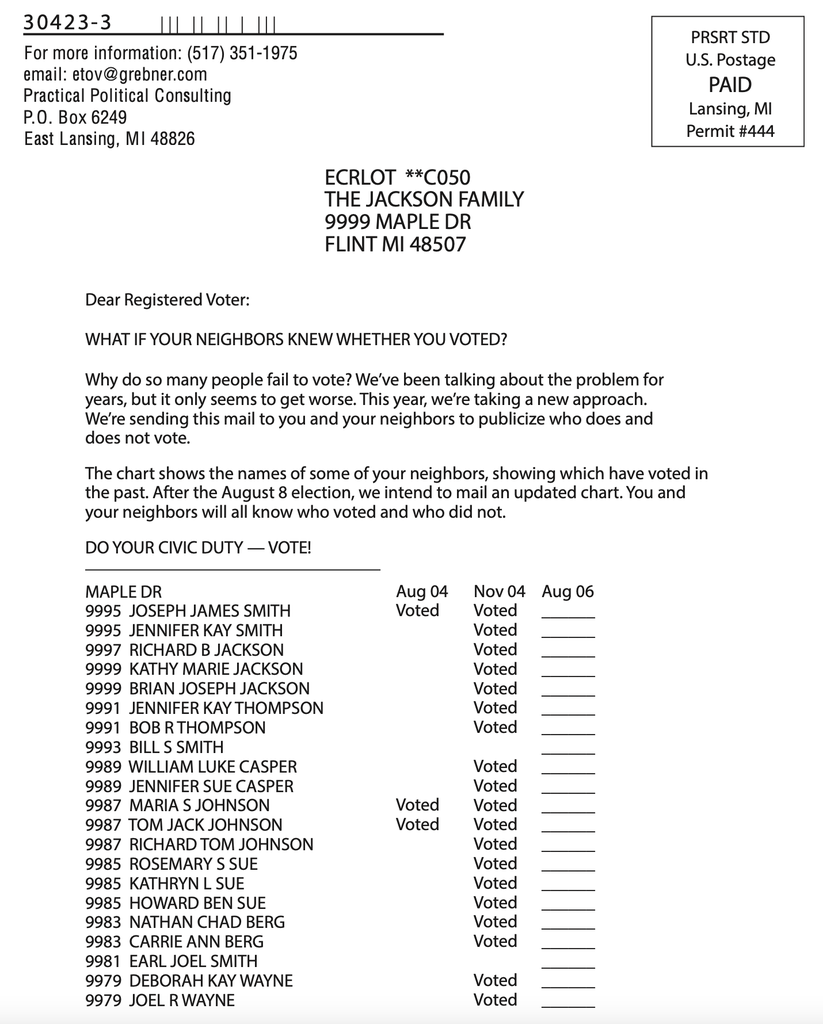

The researchers then matched individuals in their experiment to public voting records. They determined that this mailer caused an 8.1pp increase in voter turnout.

**Discussion Questions:**

1. In your opinion, what are the ethical “trouble spots” in this experiment?
2. What changes can you imagine implementing to improve the ethical design of this experiment?
3. As it turns out, the mailers were not sent to a random sample of Michigan voters. Rather, the researchers “over-treated” voters living in competitive congressional districts (where the election was particularly close). Does this change your ethical assessment of the situation?
4. What if the researchers had “overtreated” supporters of one political party?
5. Suppose that the researchers had submitted the study to IRB at institution X (which approved the proposal), but the proposed mailer differed substantially from the one that was actually used. Does this change your assessment of the research? If so, how?
6. Once the mailers had been sent, there was a public backlash in Michigan that completely surprised the research team. In fact, previous experiments with mailers had elicited no public complaints. If you were to conduct a similar study in the future, what would you do?

### Wrapping up

Any questions about your presentations for next session?

Potential topics for the remainder of the course:

- Clustered random assignments
- Non-compliance
- Attrition
- Heterogeneous treatment effects
- Mechanisms and Factorial Designs
- Interference between units (and within-subject designs)
- Confidence intervals
- Experiments within a larger dissertation project
- Multimethod research
- Generalizing Experimental Results
- Publication Bias and P-Hacking
- Evaluate similar experiments on your substantive topics

Please take a few minutes to fill out an (anonymous) [midterm evaluation survey.](https://makingdiversitywork.qualtrics.com/jfe/form/SV_eaNUmj6dzEusxv0).